# ARIMA Modeling with R

Jeff Li

2019-02-10

“I maintained my edge by always being a student; you will always have something new to learn”. - Jackie Joyner Kersee

**Course Description:**

In this course, you will become an expert in fitting ARIMA models to time series data using R. First, you will explore the nature of time series data using the tools in the R stats package. Next, you learn how to fit various ARMA models to simulated data (where you will know the correct model) using the R package astsa. Once you have mastered the basics, you will learn how to fit integrated ARMA models, or ARIMA models to various real data sets. You will learn how to check the validity of an ARIMA model and you will learn how to forecast time series data. Finally, you will learn how to fit ARIMA models to seasonal data, including forecasting using the astsa package.

Ref: Stoffer, David. (2019) “ARIMA Modeling with R”, www.datacamp.com.

## (I) Load Required Libraries

# 1. Time Series Data and Models

“You will investigate the nature of time series data and learn the basics of ARMA models that can explain the behavior of such data. You will learn the basic R commands needed to help set up raw time series data to a form that can be analyzed using ARMA models.”

## 1.1 Time series

Time series are everywehere: finance, industrial processes, nature.

- Autoregressive (AR) & Moving Average (MA): ARMA
- Integrated ARMA: ARIMA

```r
# Time Series data - 1
head(jj)
```

```
## [1] 0.71 0.63 0.85 0.44 0.61 0.69
```

```r
str(jj)
```

```
##  Time-Series [1:84] from 1960 to 1981: 0.71 0.63 0.85 0.44 0.61 0.69 0.92 0.55 0.72 0.77 ...
```

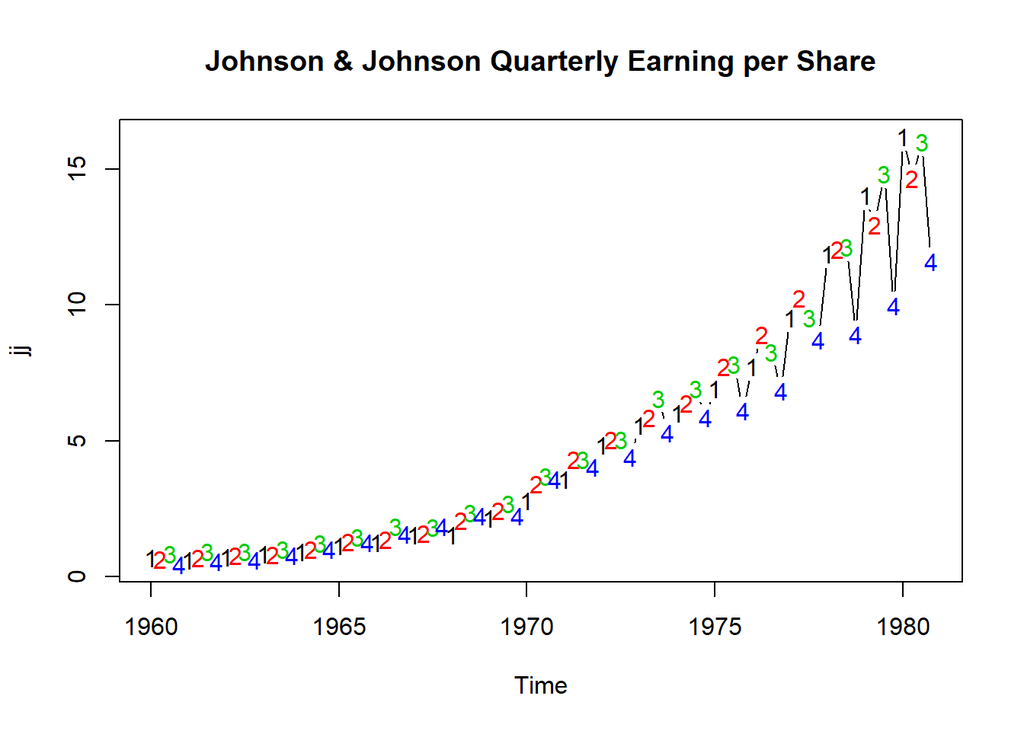

```r
plot(jj, main = "Johnson & Johnson Quarterly Earning per Share", type = "c")
text(jj, labels = 1:4, col = 1:4)
```

```r
# Time series data - II
str(globtemp)
```

```
##  Time-Series [1:136] from 1880 to 2015: -0.2 -0.11 -0.1 -0.2 -0.28 -0.31 -0.3 -0.33 -0.2 -0.11 ...
```

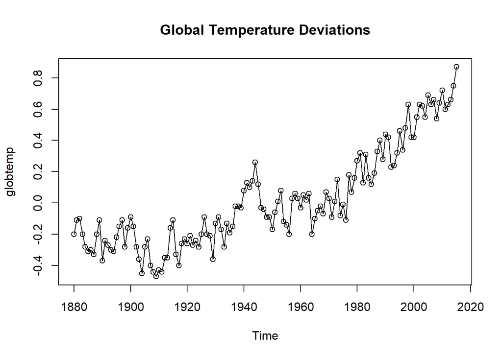

```r
plot(globtemp, main = "Global Temperature Deviations", type = "o")
```

```r
# Time series data - III
library(xts)
str(sp500w)
```

```
## An 'xts' object on 2003-01-03/2012-09-28 containing:
##   Data: num [1:509, 1] 0.03721 0.02067 -0.0282 -0.04581 -0.00664 ...
##  - attr(*, "dimnames")=List of 2
##   ..$ : NULL
##   ..$ : chr "Close"
##   Indexed by objects of class: [Date] TZ: UTC
##   xts Attributes:
## List of 1
##  $ na.action: 'exclude' num 1
```

```r
head(sp500w)
```

```
##                   Close
## 2003-01-03  0.037213025
## 2003-01-10  0.020674294
## 2003-01-17 -0.028197651
## 2003-01-24 -0.045811620
## 2003-01-31 -0.006639139
## 2003-02-07 -0.030867722
```

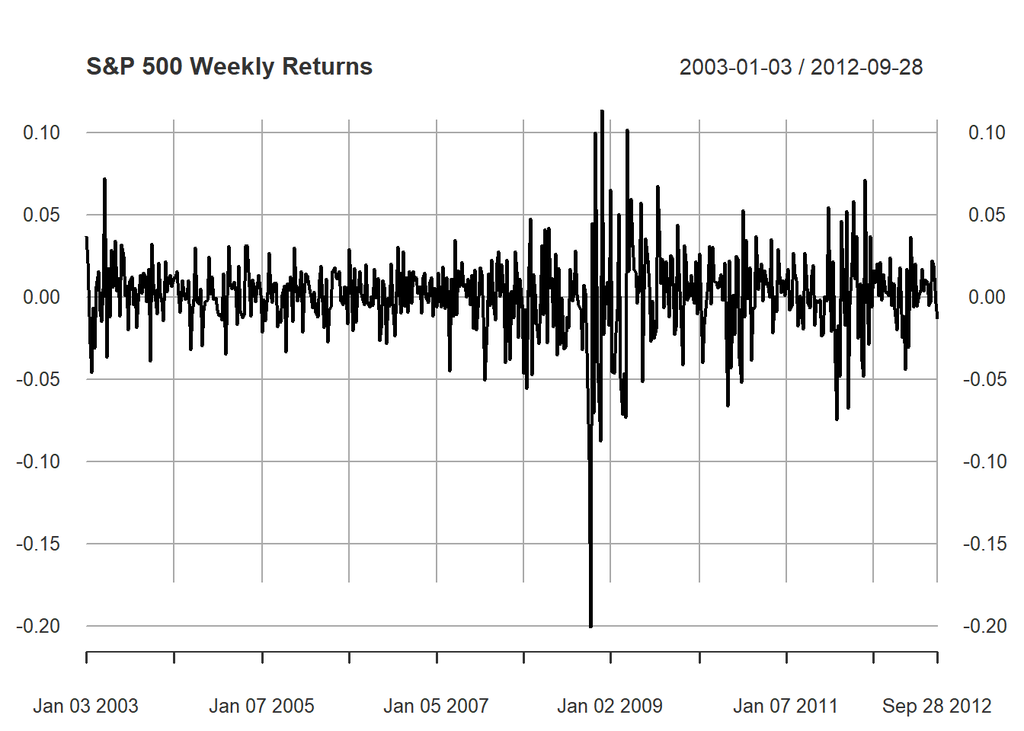

```r
plot(sp500w, main = "S&P 500 Weekly Returns")
```

## 1.2 Time Series Regression Models

Regression: $Y_i = \beta*X_i + \epsilon_i$, where $\epsilon_i$ is white noise.

White Noise:

- independent normals with commom variance
- is basic building blocks of time series

AutoRegression: $X_t = \phi * X_{t-1} + \epsilon_t$ ($\epsilon$ is white noise)

Moving Average: $\epsilon_t = W_t + \theta * W_{t-1}$ ($W_t$ is white noise)

ARMA: $X_t = \phi * X_{t-1} + W_t + \theta * W_{t-1}$

```r
# View a detailed description of AirPassengers
help(AirPassengers)
```

```
## starting httpd help server ... done
```

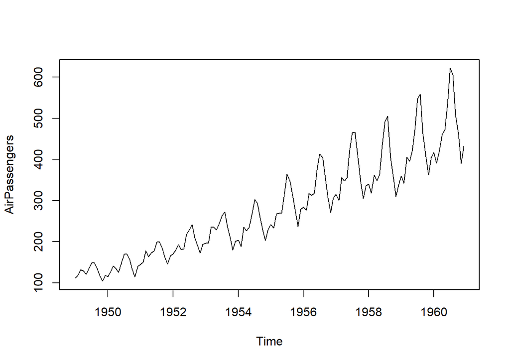

```r
# Plot AirPassengers
plot(AirPassengers)
```

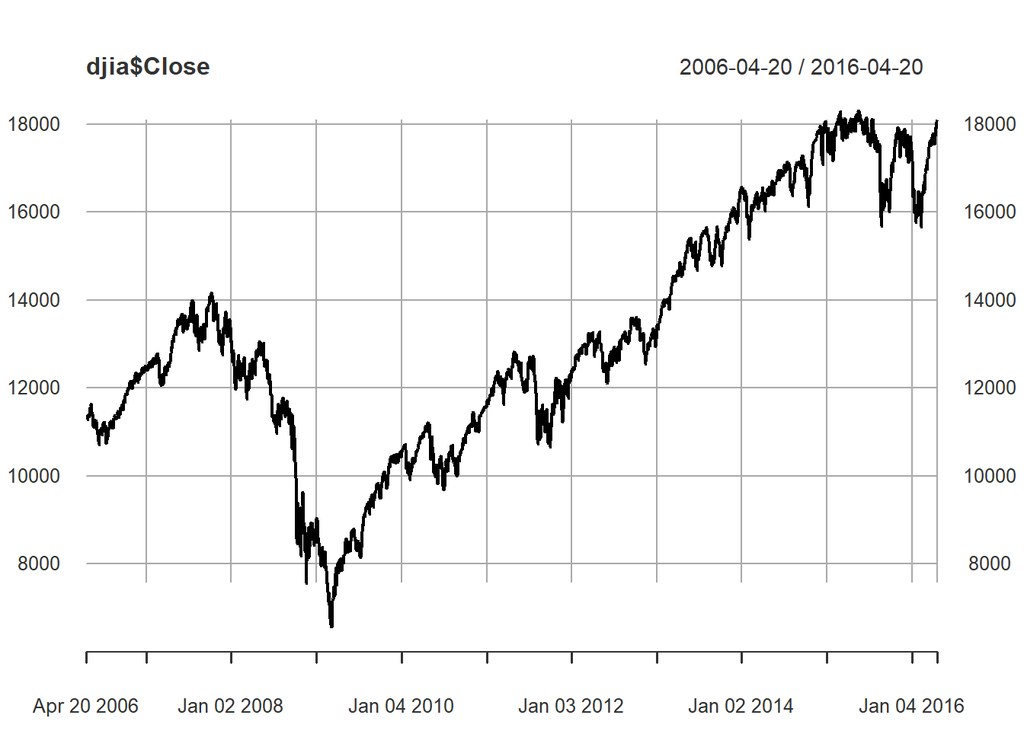

```r
# Plot the DJIA daily closings
plot(djia$Close)
```

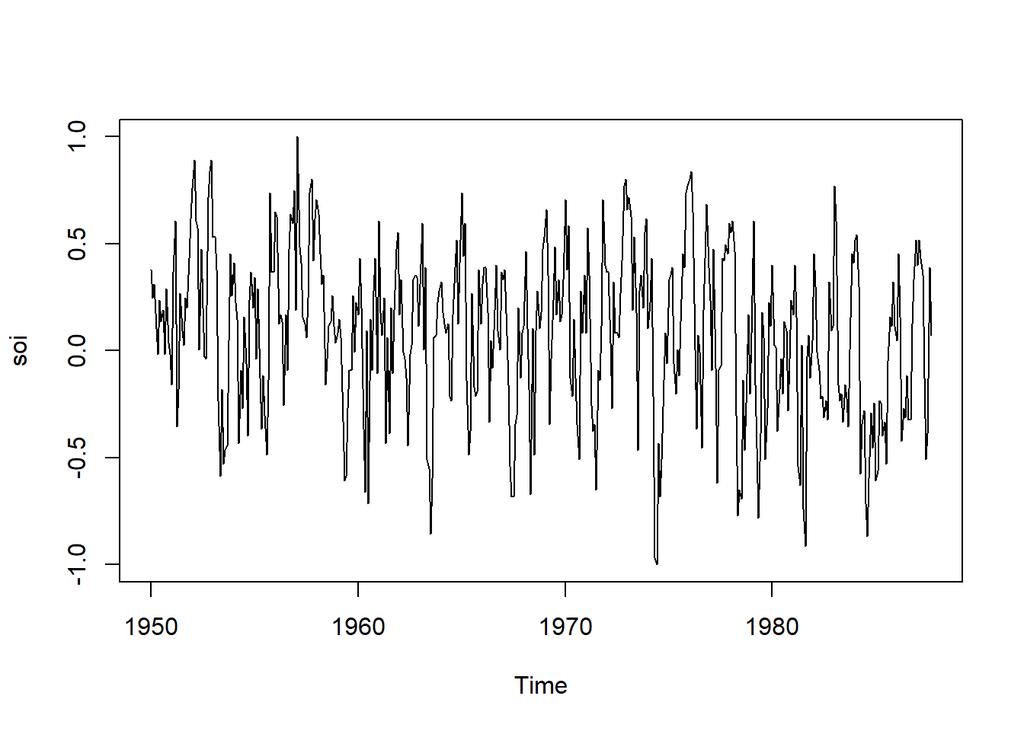

```r
# Plot the Southern Oscillation Index
plot(soi)
```

The AirPassengers data show a handful of important qualities, including seasonality, trend, and heteroscedasticity, which distinguish the data from standand white noise.

## 1.3 Stationarity and Nonstationarity

Stationarity: The mean is constant over time (no trend); the correlation structure remains constant over time.

Random Walk Trend: no stationary, but differenced data are stationary.

Trend stationarity: sationarity around a trend, differencing still works!

Nonstationarity in trend and variability: First log, then difference.

## 1.3.1 Differencing

When a time series is trend stationary, it will have stationary behavior around a trend. A simple example is $Y_t = \alpha + \beta*t + X_t$ where $X_t$ is stationary.

A different type of model for trend is *random walk*, which has the form $X_t = X_{t-1} + W_t$, where $W_t$ is white noise. It is called a random walk because at time t the process is where it was at time *t-1* plus a completely random movement. For a *random walk with drift*, a constant is added to the model and wil cause the random walk to drift in the direciton (positive or negative) of the drift.

Differencing both trend stationary and random walk data has the effect of removing the trends, despite the important differences between the two datasets.

```r
# Plot detrended y (trend stationary)
plot(diff(y))

# Plot detrended x (random walk)
plot(diff(x))
```

[output not shown]

### 1.3.2 Detrending Data

Differencing is generally good for removing trend form time series data.

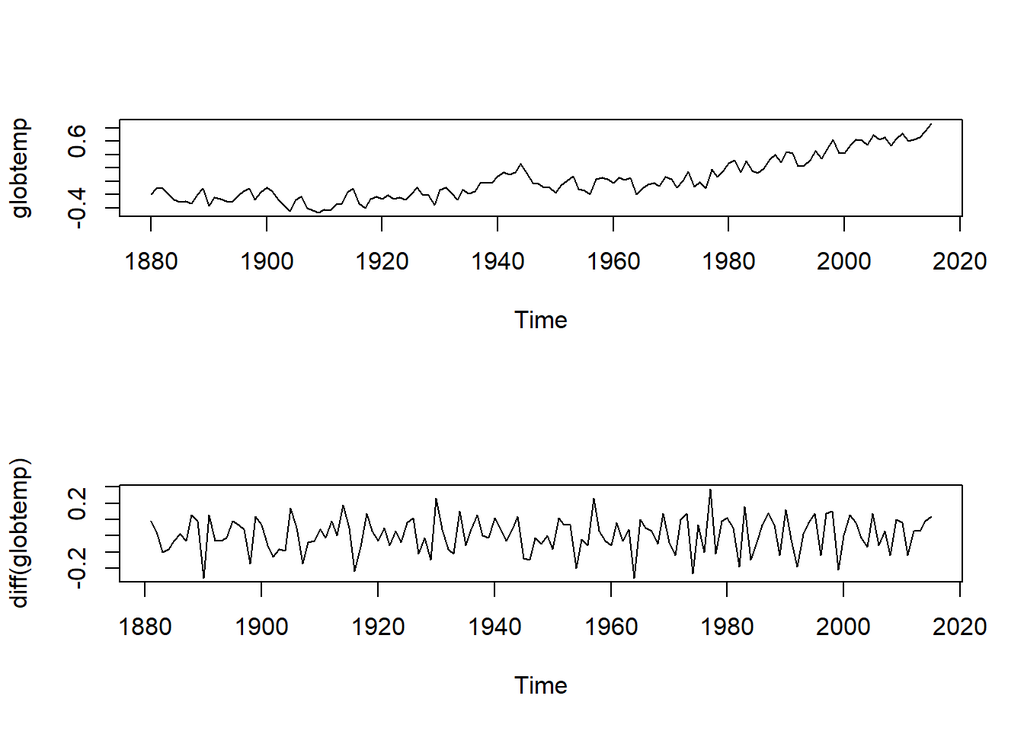

```r
# Plot globtemp and detrended globtemp
par(mfrow = c(2, 1))
plot(globtemp)
plot(diff(globtemp))
```

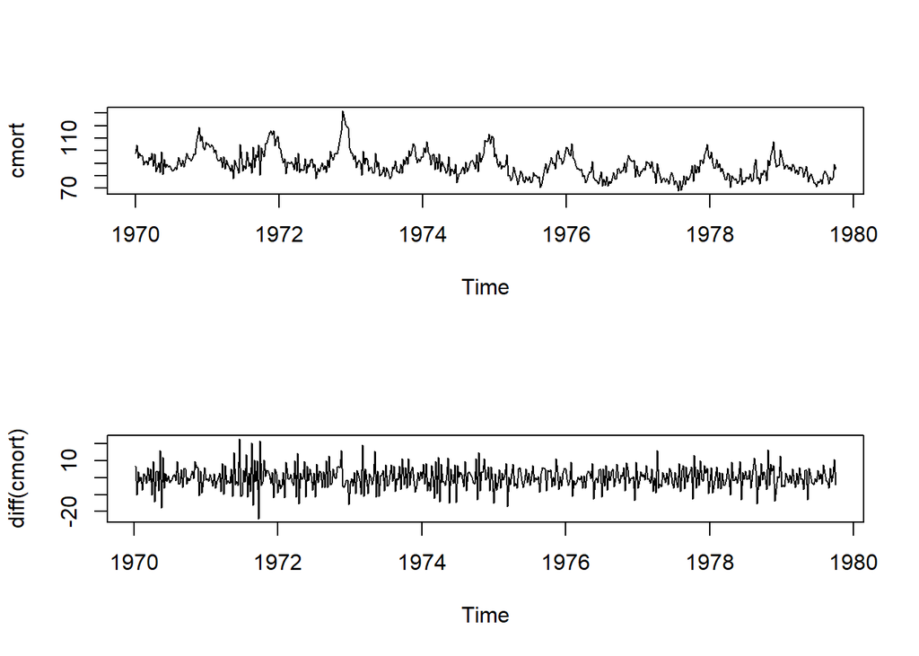

```r
# Plot cmort adn detrended cmort
par(mfrow = c(2, 1))
plot(cmort)
plot(diff(cmort))
```

## 1.3.3 Dealing with Trend and Heteroscedasticity

We can coerce nonstationary data to stationarity by calculating the return or growth rate as follows.

Ofter time series are generated as
$$X_i = (1 + p_i)X_{t-1}$$
meaning that the value of the time series observed at time t equals the value observed at time *t-1* and a small percent change *pi* at time t.

A simple deterministic example is putting money into a bank with a fixed interest p. In the case, $X_i$ is the value of the account at time period *t* with an initial deposit of $X_0$.

Typically, $p_t$ is referred to as the return or growth rate of a time series, and the process is ofter stable.

The growth rate $p_i$ can be approximately by:
$$Y_t = log(X_t) - log(X_{t-1})$$

In R, $p_t$ is ofter calculated as *diff(log(x))*

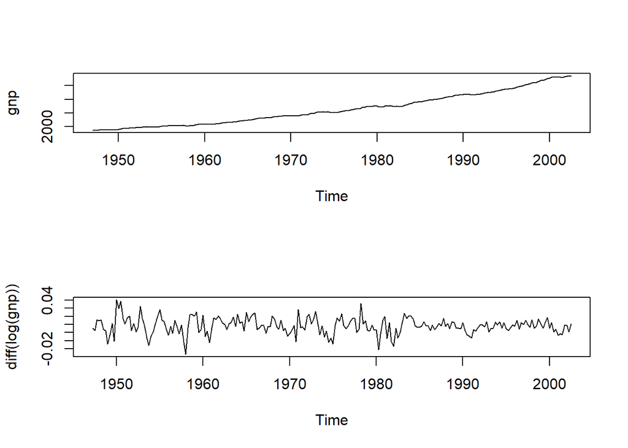

```r
# plot GNP series (gnp) and its growth rate
par(mfrow = c(2, 1))
plot(gnp)
plot(diff(log(gnp)))
```

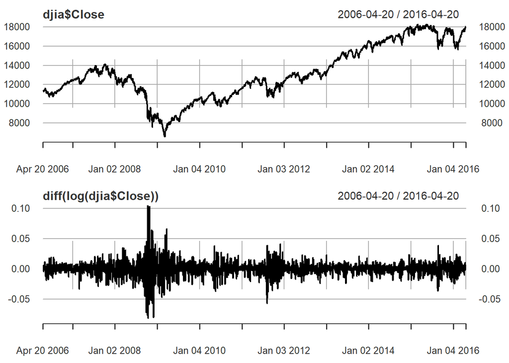

```r
# Plot DJIA closing (djia$Close) and its returns
par(mfrow = c(2, 1))
plot(djia$Close)
plot(diff(log(djia$Close)))
```